# Исследование объявлений о продаже квартир

### Количество комнат

```python
# посмторим описательную часть для столбца 'rooms'
data['rooms'].describe().T
```

```
count    23578.000000
mean         2.070956
std          1.078783
min          0.000000
25%          1.000000
50%          2.000000
75%          3.000000
max         19.000000
Name: rooms, dtype: float64
```

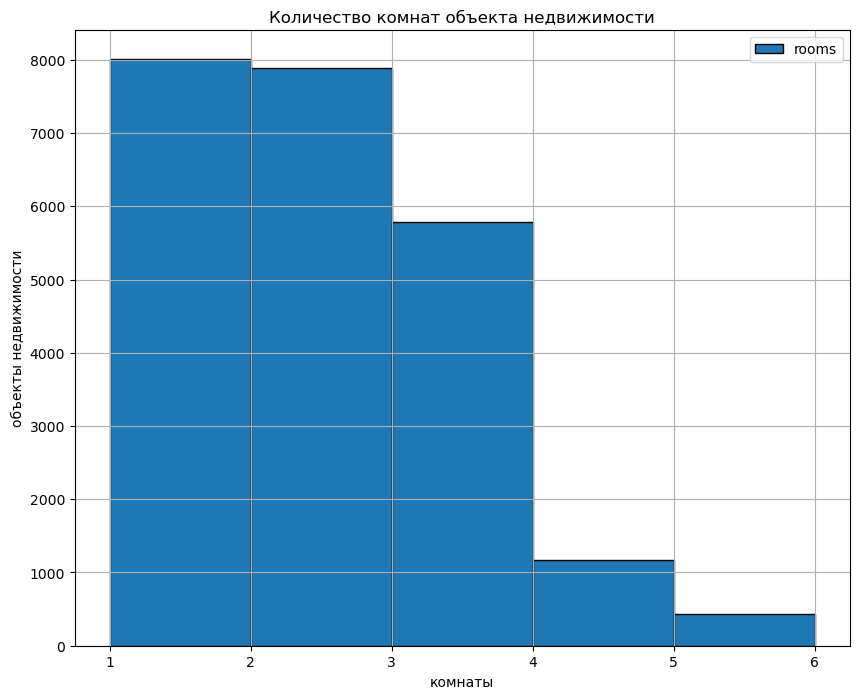

```python
# рассчитаем Q1, Q3 и IQR чтобы построить график без выбросов
# первый квартиль Q1
q1 = data['rooms'].quantile(.25)

# третий квартиль Q3
q3 = data['rooms'].quantile(.75)

# межквартильный размах IQR
iqr = q3 - q1

# построим гистограмму кол-ва комнат
data['rooms'].hist(bins=5, range=(1, (q3 + 1.5 * iqr)), figsize=(10, 8), ec='black', legend=True)
plt.title('Количество комнат объекта недвижимости')
plt.xlabel('комнаты')
plt.ylabel('объекты недвижимости')
plt.show()
```

**Вывод:**

Рассматриваемый диапазо, от 1 до 5 комнат, исключая некорректные значения (0 комнат) и выбросы. Большая часть объектов недвижимости имеют 1 или 2 комнаты, чуть меньше - 3 комнаты. Объектов, с кол-вом комнат 4-5 относительно немного. Среднее и медиана 2 комнаты точны. Крайне редкие значения (от 6 до 19 комнат) не оказывают существенного влияния на среднее значение.

### Высота потолков

```python
# посмторим описательную часть для столбца 'ceiling_height'

data['ceiling_height'].describe().T
```

```
count    23578.000000
mean         2.697155
std          0.215109
min          2.500000
25%          2.600000
50%          2.650000
75%          2.700000
max          5.000000
Name: ceiling_height, dtype: float64
```

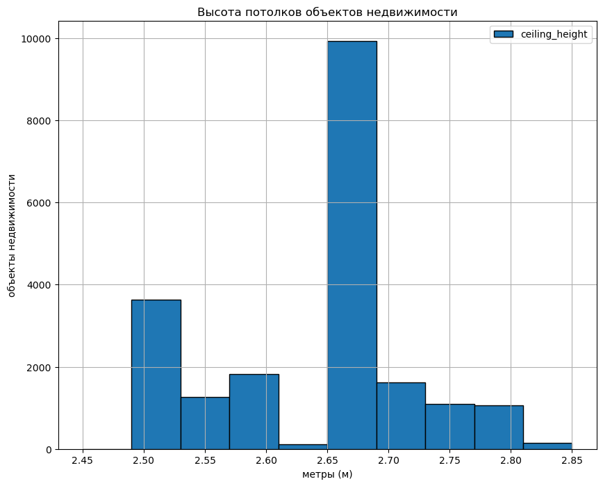

```python
# рассчитаем Q1, Q3 и IQR для построения графика без выбросов
# первый квартиль Q1
q1 = data['ceiling_height'].quantile(.25)

# третий квартиль Q3
q3 = data['ceiling_height'].quantile(.75)

# межквартильный размах IQR
iqr = q3 - q1

# построим гистограмму высоты потолков
data['ceiling_height'].hist(bins=10, range=((q1 - 1.5 * iqr), (q3 + 1.5 * iqr)), figsize=(10, 8), ec='black', legend=True)
plt.title('Высота потолков объектов недвижимости')
plt.xlabel('метры (м)')
plt.ylabel('объекты недвижимости')
plt.show()
```

**Вывод**

Рассматриваем диапазон от 2,5 до 2,85 м, исключая некорректные значения и выбросы. Большинство объектов недвижимости имеют высоту потолков 2,5 м и 2,65 м (большинство). Реже представлены варианты от 2,7м до 2,85 м. Среднее 2,7 м и медиана 2,65 точны.

### Этаж квартиры

```python
# посмторим описательную часть для столбца 'floor'

data['floor'].describe().T
```

```
count    23578.000000
mean         5.881245
std          4.861659
min          1.000000
25%          2.000000
50%          4.000000
75%          8.000000
max         27.000000
Name: floor, dtype: float64
```

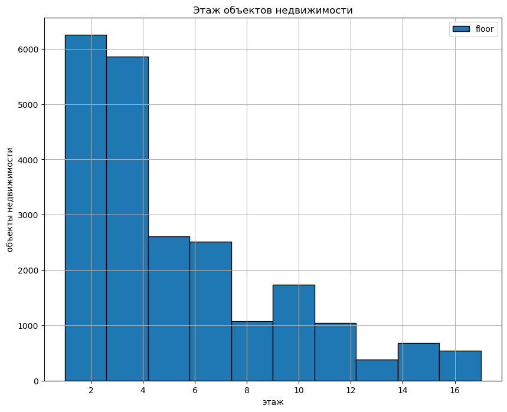

```python
# рассчитаем Q1, Q3 и IQR для построения графика без выбросов
# первый квартиль Q1
q1 = data['floor'].quantile(.25)

# третий квартиль Q3
q3 = data['floor'].quantile(.75)

# межквартильный размах IQR
iqr = q3 - q1

# построим гистограмму этажа квартиры
data['floor'].hist(bins=10, range=(1, (q3 + 1.5 * iqr)), figsize=(10, 8), ec='black', legend=True)
plt.title('Этаж объектов недвижимости')
plt.xlabel('этаж')
plt.ylabel('объекты недвижимости')
plt.show()
```

**Вывод**

Рассматриваемый диапазон с 1 по 17 этаж, исключая некорректные значения и выбросы. Большинство объектов недвижимости расположены с 1 по 4 этаж. Реже представлены варианты с 4 по 7. Среднее 5 этаж и медиана 4 этаж.

### Тип этажа квартиры («первый», «последний», «другой»)

```python
# напомним как мы обозначили столбец с категоризацией по типу квартиры

data.head()
```

|  | total_images | last_price | total_area | first_day_exposition | rooms | ceiling_height | floors_total | living_area | floor | is_apartment | studio | open_plan | kitchen_area | balcony | locality_name | airports_nearest | city_centers_nearest | parks_around_3000 | parks_nearest | ponds_around_3000 | ponds_nearest | days_exposition | price_one_square_meter | exposition_weekday | exposition_month | exposition_year | floor_category | city_centers_nearest_km |
| --- | --- | --- | --- | --- | --- | --- | --- | --- | --- | --- | --- | --- | --- | --- | --- | --- | --- | --- | --- | --- | --- | --- | --- | --- | --- | --- | --- | --- |
| 0 | 20 | 13 | 108.000000 | 2019-03-07 | 3 | 2.70 | 16.0 | 51.000000 | 8 | False | False | False | 25.0 | 0 | Санкт-Петербург | 18863.0 | 16028.0 | 1.0 | 482.0 | 2.0 | 755.0 | NaN | 0.12 | 3 | 3 | 2019 | другой | 16.0 |
| 1 | 7 | 3 | 40.400002 | 2018-12-04 | 1 | 2.65 | 11.0 | 18.600000 | 1 | False | False | False | 11.0 | 2 | посёлок Шушары | 12817.0 | 18603.0 | 0.0 | NaN | 0.0 | NaN | 81.0 | 0.07 | 1 | 12 | 2018 | первый | 19.0 |
| 2 | 10 | 5 | 56.000000 | 2015-08-20 | 2 | 2.65 | 5.0 | 34.299999 | 4 | False | False | False | 8.3 | 0 | Санкт-Петербург | 21741.0 | 13933.0 | 1.0 | 90.0 | 2.0 | 574.0 | 558.0 | 0.09 | 3 | 8 | 2015 | другой | 14.0 |
| 3 | 0 | 64 | 159.000000 | 2015-07-24 | 3 | 2.65 | 14.0 | NaN | 9 | False | False | False | NaN | 0 | Санкт-Петербург | 28098.0 | 6800.0 | 2.0 | 84.0 | 3.0 | 234.0 | 424.0 | 0.40 | 4 | 7 | 2015 | другой | 7.0 |
| 4 | 2 | 10 | 100.000000 | 2018-06-19 | 2 | 3.03 | 14.0 | 32.000000 | 13 | False | False | False | 41.0 | 0 | Санкт-Петербург | 31856.0 | 8098.0 | 2.0 | 112.0 | 1.0 | 48.0 | 121.0 | 0.10 | 1 | 6 | 2018 | другой | 8.0 |

```python
# вызовем describe

data['floor_category'].describe().T
```

```
count      23578
unique         3
top       другой
freq       17363
Name: floor_category, dtype: object
```

```python
# посмотрим на кол-во в каждой категории

data['floor_category'].value_counts()
```

```
floor_category
другой       17363
последний     3313
первый        2902
Name: count, dtype: int64
```

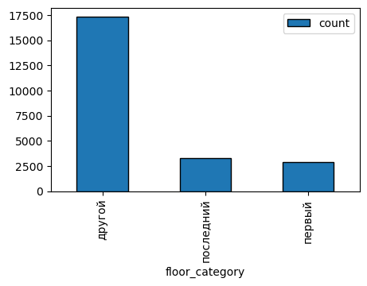

```python
# отобразим это на графике

data['floor_category'].value_counts().plot.bar(figsize=(5, 3), ec='black', legend=True)
plt.show()
```

**Вывод**

Видно, что объекты недвижимости, расположенные на первом и последним этажах имеют примерно одинаковые значения и их доля не столь велика. В основном объекты расположены на этажах между первым и последним.*

### Общее количество этажей в доме

```python
# выведем описательную статистику столбца 'floors_total'

data['floors_total'].describe()
```

```
count    23492.000000
mean        10.650945
std          6.535243
min          1.000000
25%          5.000000
50%          9.000000
75%         16.000000
max         29.000000
Name: floors_total, dtype: float64
```

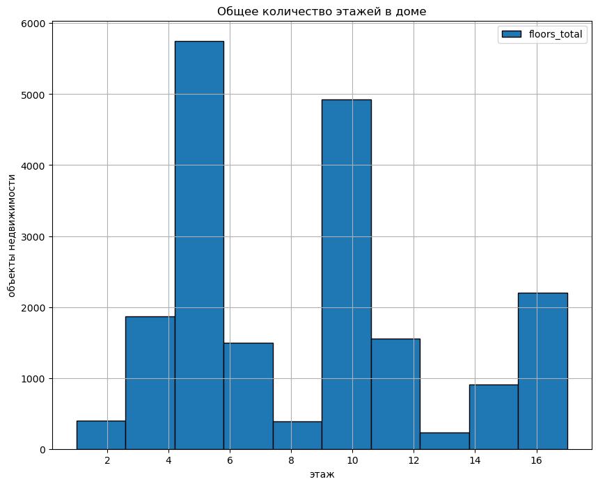

```python
# рассчитаем Q1, Q3 и IQR для построения графика без выбросов
# первый квартиль Q1
q1 = data['floor'].quantile(.25)

# третий квартиль Q3
q3 = data['floor'].quantile(.75)

# межквартильный размах IQR
iqr = q3 - q1

# построим гистограмму общего кол-ва этажей в доме
data['floors_total'].hist(bins=10, range=(1, (q3 + 1.5 * iqr)), figsize=(10, 8), ec='black', legend=True)
plt.title('Общее количество этажей в доме')
plt.xlabel('этаж')
plt.ylabel('объекты недвижимости')
plt.show()
```

**Вывод:**

Рассматриваемый диапазон с 1 по 17 этаж, исключая некорректные значения и выбросы. Большинство объектов недвижимости - это 5-ти , 9-ти этажки. Остальные варианты представлены реже. Среднее 10 этаж и медиана 9 этаж.

### Расстояние до центра города в метрах

```python
# выведем описательную статистику столбца 'city_centers_nearest'

data['city_centers_nearest'].describe()
```

```
count    18091.000000
mean     14179.978516
std       8608.557617
min        181.000000
25%       9234.000000
50%      13090.000000
75%      16280.000000
max      65968.000000
Name: city_centers_nearest, dtype: float64
```

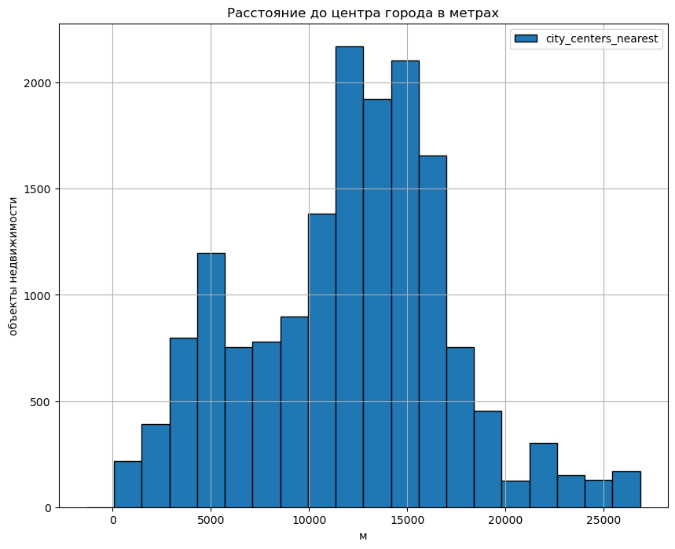

```python
# рассчитаем Q1, Q3 и IQR для построения графика без выбросов
# первый квартиль Q1
q1 = data['city_centers_nearest'].quantile(.25)

# третий квартиль Q3
q3 = data['city_centers_nearest'].quantile(.75)

# межквартильный размах IQR
iqr = q3 - q1

# построим гистограмму этажа квартиры
data['city_centers_nearest'].hist(bins=20, range=((q1 - 1.5 * iqr), (q3 + 1.5 * iqr)), figsize=(10, 8), ec='black', legend=True)
plt.title('Расстояние до центра города в метрах')
plt.xlabel('м')
plt.ylabel('объекты недвижимости')
plt.show()
```

**Вывод**

### Расстояние до ближайшего аэропорта

```python
# уберем значения равные 0

data = data.query('airports_nearest != 0')
```

```python
# выведем описательную статистику для столбца 'airports_nearest'

data['airports_nearest'].describe()
```

```
count    18067.000000
mean     28816.652344
std      12633.223633
min       6450.000000
25%      18575.500000
50%      26765.000000
75%      37310.000000
max      84869.000000
Name: airports_nearest, dtype: float64
```

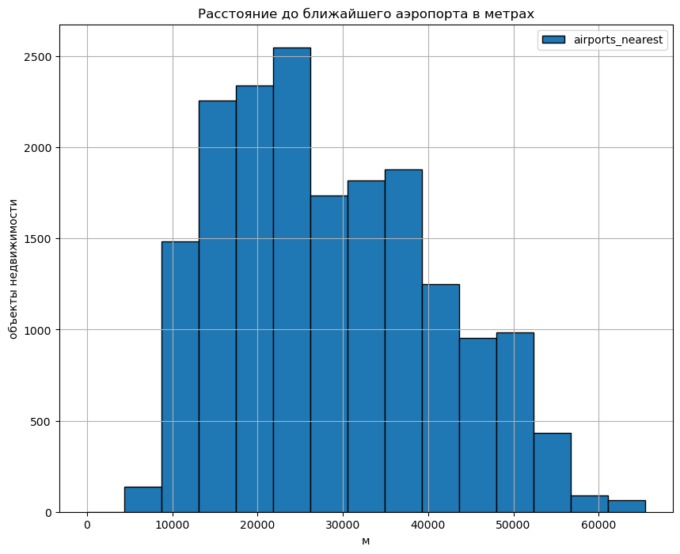

```python
# рассчитаем Q1, Q3 и IQR для построения графика без выбросов
# первый квартиль Q1
q1 = data['airports_nearest'].quantile(.25)

# третий квартиль Q3
q3 = data['airports_nearest'].quantile(.75)

# межквартильный размах IQR
iqr = q3 - q1

# построим гистограмму этажа квартиры
data['airports_nearest'].hist(bins=15, range=(0, (q3 + 1.5 * iqr)), figsize=(10, 8), ec='black', legend=True)
plt.title('Расстояние до ближайшего аэропорта в метрах')
plt.xlabel('м')
plt.ylabel('объекты недвижимости')
plt.show()
```

**Вывод**

Рассматриваемый диапазон с 0 до 65000 м. Большинство объектов недвижимости расположены на удалении от аэропорта на расстоянии 15-25 км. Ближайший к аэропорту объект на расстоянии 6,5 км. Среднее 28,8 км и медиана 26,7 км.

### Расстояние до ближайшего парка в метрах

```python
data.head(3)
```

|  | total_images | last_price | total_area | first_day_exposition | rooms | ceiling_height | floors_total | living_area | floor | is_apartment | studio | open_plan | kitchen_area | balcony | locality_name | airports_nearest | city_centers_nearest | parks_around_3000 | parks_nearest | ponds_around_3000 | ponds_nearest | days_exposition | price_one_square_meter | exposition_weekday | exposition_month | exposition_year | floor_category | city_centers_nearest_km |
| --- | --- | --- | --- | --- | --- | --- | --- | --- | --- | --- | --- | --- | --- | --- | --- | --- | --- | --- | --- | --- | --- | --- | --- | --- | --- | --- | --- | --- |
| 0 | 20 | 13 | 108.000000 | 2019-03-07 | 3 | 2.70 | 16.0 | 51.000000 | 8 | False | False | False | 25.0 | 0 | Санкт-Петербург | 18863.0 | 16028.0 | 1.0 | 482.0 | 2.0 | 755.0 | NaN | 0.12 | 3 | 3 | 2019 | другой | 16.0 |
| 1 | 7 | 3 | 40.400002 | 2018-12-04 | 1 | 2.65 | 11.0 | 18.600000 | 1 | False | False | False | 11.0 | 2 | посёлок Шушары | 12817.0 | 18603.0 | 0.0 | NaN | 0.0 | NaN | 81.0 | 0.07 | 1 | 12 | 2018 | первый | 19.0 |
| 2 | 10 | 5 | 56.000000 | 2015-08-20 | 2 | 2.65 | 5.0 | 34.299999 | 4 | False | False | False | 8.3 | 0 | Санкт-Петербург | 21741.0 | 13933.0 | 1.0 | 90.0 | 2.0 | 574.0 | 558.0 | 0.09 | 3 | 8 | 2015 | другой | 14.0 |

```python
# посмотрим описательную статистику столбуа 'parks_nearest'

data['parks_nearest'].describe().T
```

```
count    8038.000000
mean      490.860168
std       342.944458
min         1.000000
25%       287.250000
50%       454.000000
75%       612.000000
max      3190.000000
Name: parks_nearest, dtype: float64
```

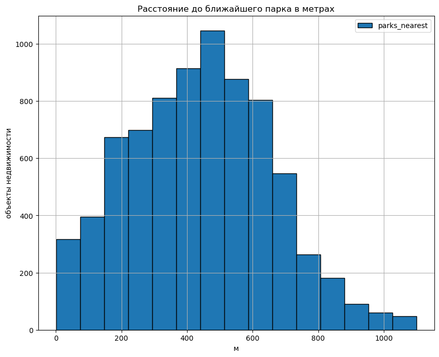

```python
# рассчитаем Q1, Q3 и IQR для построения графика без выбросов
# первый квартиль Q1
q1 = data['parks_nearest'].quantile(.25)

# третий квартиль Q3
q3 = data['parks_nearest'].quantile(.75)

# межквартильный размах IQR
iqr = q3 - q1

# построим гистограмму этажа квартиры
data['parks_nearest'].hist(bins=15, range=(1, (q3 + 1.5 * iqr)), figsize=(10, 8), ec='black', legend=True)
plt.title('Расстояние до ближайшего парка в метрах')
plt.xlabel('м')
plt.ylabel('объекты недвижимости')
plt.show()
```

**Вывод**

### День и месяц публикации объявления

День публикации объявления

```python
# посмотрим описательную статистику столбца 'exposition_weekday'

data['exposition_weekday'].describe().T
```

```
count    23577.000000
mean         2.569072
std          1.788719
min          0.000000
25%          1.000000
50%          3.000000
75%          4.000000
max          6.000000
Name: exposition_weekday, dtype: float64
```

```python
# посмотрим кол-во объявлений по каждому дню недели

data['exposition_weekday'].value_counts().sort_values()
```

```
exposition_weekday
6    1685
5    1933
0    3591
2    3956
4    3978
1    4165
3    4269
Name: count, dtype: int64
```

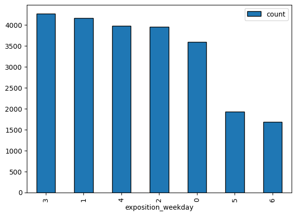

```python
# отобразим это на графике

data['exposition_weekday'].value_counts().plot.bar(figsize=(7, 5), ec='black', legend=True)
plt.show()
```

**Вывод**

По графику видно, что чаще всего объявления публиковали в будние дни в середине недели. Реже в выходные дни.

### Месяц публикации объявления

```python
# посмотрим описательную статистику столбца 'exposition_month'

data['exposition_month'].describe().T
```

```
count    23577.000000
mean         6.399203
std          3.491742
min          1.000000
25%          3.000000
50%          6.000000
75%         10.000000
max         12.000000
Name: exposition_month, dtype: float64
```

```python
# посмотрим кол-во объявлений по каждому дню недели

data['exposition_month'].value_counts().sort_values()
```

```
exposition_month
5     1267
1     1493
12    1635
7     1689
8     1733
6     1751
9     1970
10    2114
11    2356
4     2367
3     2575
2     2627
Name: count, dtype: int64
```

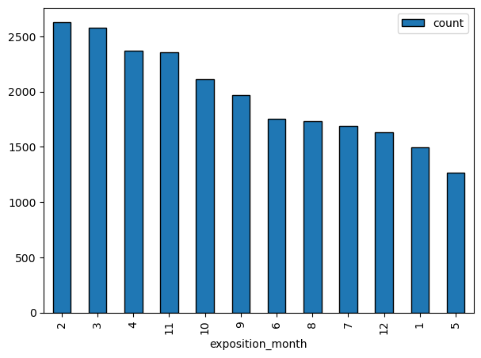

```python
# отобразим это на графике

data['exposition_month'].value_counts().plot.bar(figsize=(7, 5), ec='black', legend=True)
plt.show()
```

**Промежуточный вывод**

По графику видно, что чаще всего объявления публиковали после январских праздников, в феврале. Наименьшие показатели в январе и мае. Можно предположить, что это из-за большого кол-ва выходных и праздничных дней.

**Вывод:**

Я получил представление о типичном объекте недвижимости из исходных данных:

- квартира с 1 или 2 комнатами, 5-ти или 9-ти этажка (с квартирой с 1 по 4 этаж);
- общей площадью около 45 м²;
- площадью кухни около 5,5 м²;
- с высотой потолков 2,6 м;
- стоимостью около 3.5 млн. руб;
- расположенной на удалении от центра на расстоянии 11000-16000 метров;
- от аэропорта на расстоянии 15000-25000 м, до ближайшего парка около 500 метров.

### Изучим, как быстро продавались квартиры (столбец days_exposition)

Этот параметр показывает, сколько дней было размещено каждое объявление:

- Построим гистограмму.
- Посчитаем среднее и медиану.
- В ячейке типа markdown опишем, сколько времени обычно занимает продажа. Какие продажи можно считать быстрыми, а какие — необычно долгими?

**Проанализируем время продажи квартиры**

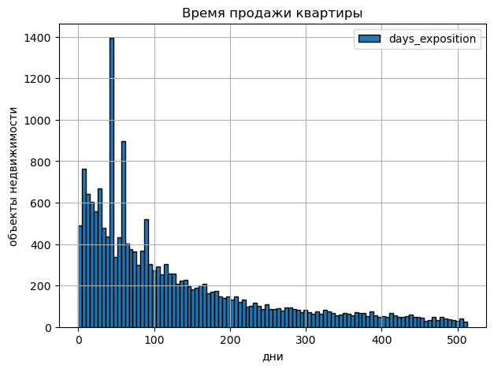

```python
# рассчитаем Q1, Q3 и IQR для построения графика без выбросов

# первый квартиль Q1
q1 = data['days_exposition'].quantile(.25)

# третий квартиль Q3
q3 = data['days_exposition'].quantile(.75)

# межквартильный размах IQR
iqr = q3 - q1

# построим гистограмму времени продажи квартиры
data['days_exposition'].hist(bins=100, range=(0, (q3 + 1.5 * iqr)), figsize=(7, 5), ec='black', legend=True)
plt.title('Время продажи квартиры')
plt.xlabel('дни')
plt.ylabel('объекты недвижимости')
plt.show()
```

**Вывод**

На графике видны пики около 50-60 дней, но при таком длинном "хвосте" из данных делать выводы не уместно. Изменим масштаб - изменим период до 100 дней.

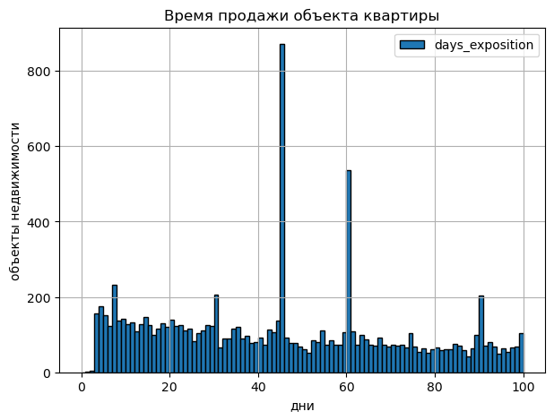

```python
# ограничим гистограмму периодом до 100 дней

data['days_exposition'].hist(bins=100, range=(0, 100), figsize=(7, 5), ec='black', legend=True)
plt.title('Время продажи объекта квартиры')
plt.xlabel('дни')
plt.ylabel('объекты недвижимости')
plt.show()
```

**Вывод**

Судя по графику, чаще всего квартиры продают за 45 и 60 дней. Но тут важно учесть, что возможно квартира не продана, а просто закрылось объявление в связи с истекшим сроком публикации. Также объявление может остаться на сайте, даже если объект недвижимости уже фактически продан, просто забыли снять объявление. В этом случае если пользователь не потдвердит актуальность объявления, оно может быть автоматически удалено.

**Теперь посмотрим на среднее и медиану**

```python
# получим описательную статистику столбца days_exposition

data['days_exposition'].describe().T
```

```
count    20416.000000
mean       180.976242
std        219.956726
min          1.000000
25%         45.000000
50%         95.000000
75%        232.000000
max       1580.000000
Name: days_exposition, dtype: float64
```

**Вывод**

Среднее время продажи объекта недвижимости 181 день, медианное - 95 дней. Максимальное значение - 1580 дней. Смотря на график, можно увидеть длиный "хвост". Больших значений достаточно много. Среднее значение в 2 раза больше медианного. Стандартное отклонение превышает среднее значение - это говорит о большом кол-ве выбросов. Чтобы посмотреть на всю эту красоту нужно построить диаграмму размаха.

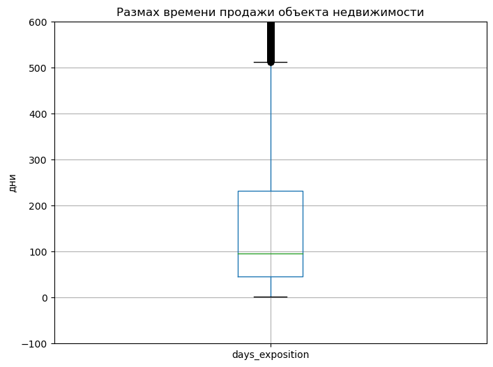

```python
# потроим диаграмму размаха времени продажи объекта недвижимости

data.boxplot(column='days_exposition', figsize=(8, 6))
plt.title('Размах времени продажи объекта недвижимости')
plt.ylim(-100, 600)
plt.ylabel('дни')
plt.show()
```

```python
# все, что выше этого значения - это выбросы

print('\033[1m' + 'Значение отсекающее выбросы:' + '\033[0m', q3 + 1.5 * iqr)
```

```
Значение отсекающее выбросы: 512.5
```

```python
len(data)
```

```
23577
```

**Обновим датафрейм без выбросов**

```python
# убираем выбросы

data_update = data.query('days_exposition < 510')

# проверим длину датафрейма

print('\033[1m' + 'Количество строк после удаления:' + '\033[0m', len(data_update))
```

```
Количество строк после удаления: 18737
```

```python
print('\033[1m' + 'Количество удаленных строк:' + '\033[0m', 23528-18694)
```

[output not shown]

**Вывод**

Оценка времени продажи:

- быстрая продажа - до 45 дней,
- нормальная продажа - от 45 до 231 дней,
- долгая продажа - от 231 до 510 дней.

*Продажи после 510 дней - выбросы.*

### Проанализируем факторы влияющие на общую стоимость объекта

**Изучим зависимость цены от:**

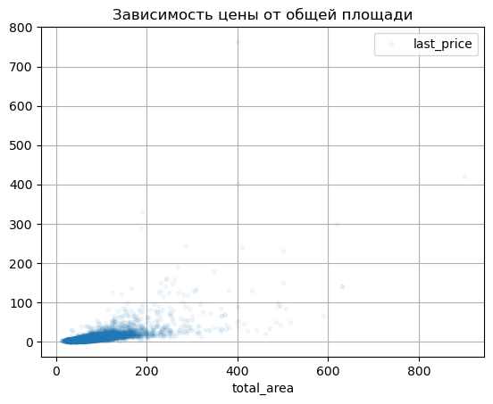

```python
# визуализируем зависимость цены от общей площади

data.plot(x='total_area', y='last_price',\
                  style='.', title='Зависимость цены от общей площади',\
                  alpha=0.05, grid=True, sharex=False)
plt.show()
```

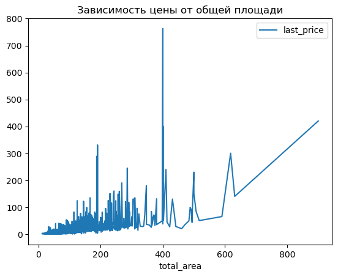

```python
# визуализируем зависимость цены от жилой площади

data.sort_values('total_area').plot(x='total_area', y='last_price',\
    style='-', title='Зависимость цены от общей площади')
plt.show()
```

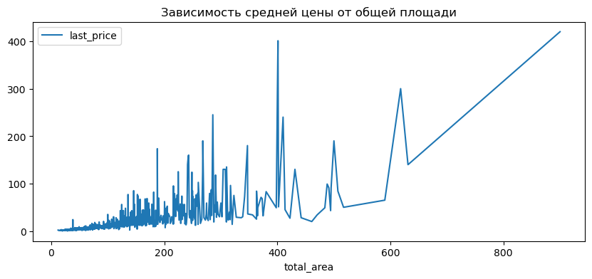

```python
# визуализируем зависимость средней цены от жилой площади

data.pivot_table(index='total_area', values='last_price')\
.plot(style='-',title='Зависимость средней цены от общей площади', figsize=(10,4))
plt.show()
```

**Вывод**

```
Коэффициент корреляции цены от площади кухни 0.52
```

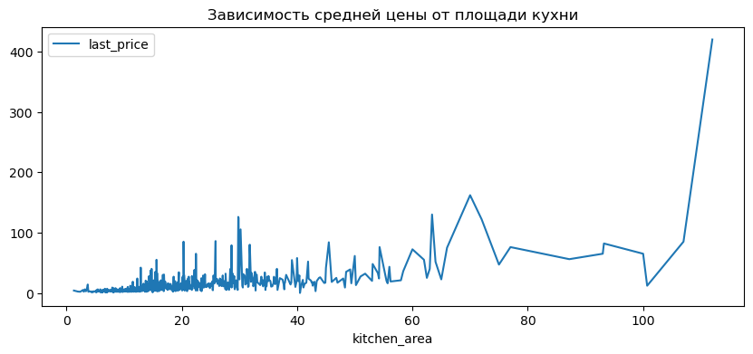

```python
# визуализируем зависимость средней цены от площади кухни

data.pivot_table(index='kitchen_area', values='last_price')\
.plot(style='-',title='Зависимость средней цены от площади кухни', figsize=(10,4))
plt.show
print('Коэффициент корреляции цены от площади кухни', round(data['kitchen_area'].corr(data['last_price']), 2))
```

```
Коэффициент корреляции цены от этажа 0.03
```

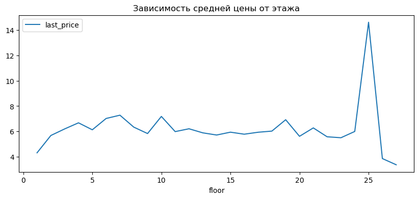

```python
# визуализируем зависимость цены от этажа

data.pivot_table(index='floor', values='last_price')\
.plot(style='-',title='Зависимость средней цены от этажа', figsize=(10,4))
plt.show
print('Коэффициент корреляции цены от этажа', round(data['floor'].corr(data['last_price']), 2))
```

```
Коэффициент корреляции цены от количества комнат 0.36
```

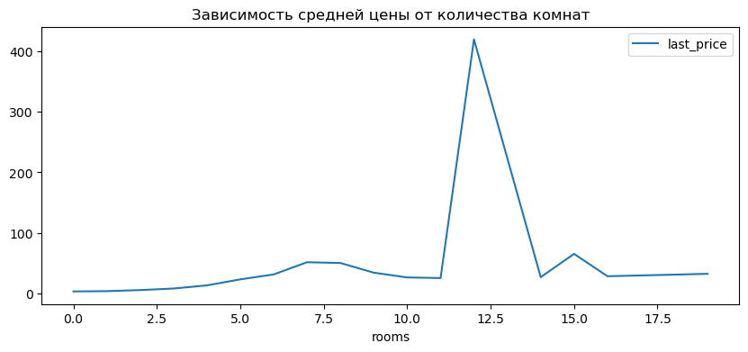

```python
# визуализируем зависимость цены от количества комнат

data.pivot_table(index='rooms', values='last_price')\
.plot(style='-',title='Зависимость средней цены от количества комнат', figsize=(10,4))
plt.show
print('Коэффициент корреляции цены от количества комнат', round(data['rooms'].corr(data['last_price']), 2))
```

**Вывод**

```python
data.pivot_table(index='floor_category', values='last_price', aggfunc='median')
```

| floor_category | last_price |
| --- | --- |
| другой | 4 |
| первый | 3 |
| последний | 4 |

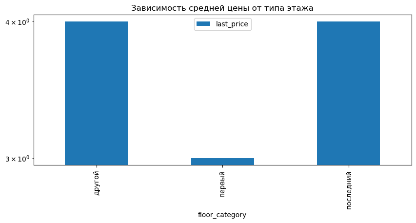

```python
# для наглядности используем логарифмическую шкалу

data.pivot_table(index='floor_category', values='last_price', aggfunc=('median'))\
.plot(style='-',title='Зависимость средней цены от типа этажа', figsize=(10,4), kind='bar', logy=True)
plt.show()
```

**Вывод**

```
Коэффициент корреляции цены от дня недели размещения объявления 0.0
```

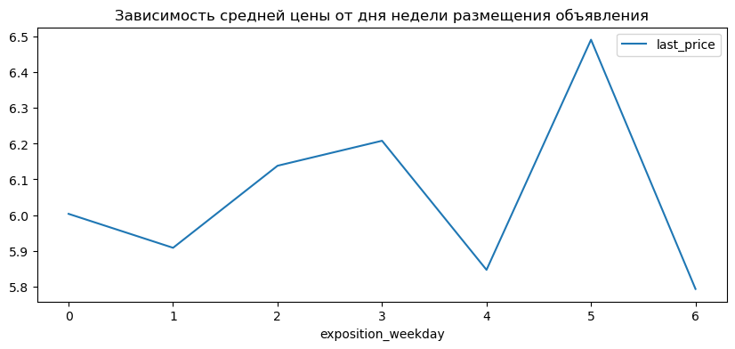

```python
data.pivot_table(index='exposition_weekday', values='last_price')\
.plot(style='-',title='Зависимость средней цены от дня недели размещения объявления', figsize=(10,4))
plt.show
print('Коэффициент корреляции цены от дня недели размещения объявления', round(data['exposition_weekday'].corr(data['last_price']), 2))
```

**Вывод**

Очевидно, что анализ показал полное отсутствие зависимости цены от дня недели*

```
Коэффициент корреляции цены от месяца размещения объявления 0.0
```

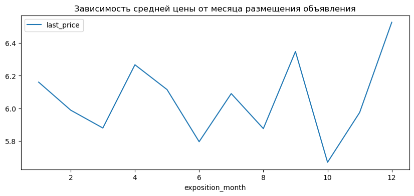

```python
data.pivot_table(index='exposition_month', values='last_price')\
.plot(style='-',title='Зависимость средней цены от месяца размещения объявления', figsize=(10,4))
plt.show
print('Коэффициент корреляции цены от месяца размещения объявления', round(data['exposition_month'].corr(data['last_price']), 2))
```

**Вывод**

```
Коэффициент корреляции цены от года размещения объявления -0.04
```

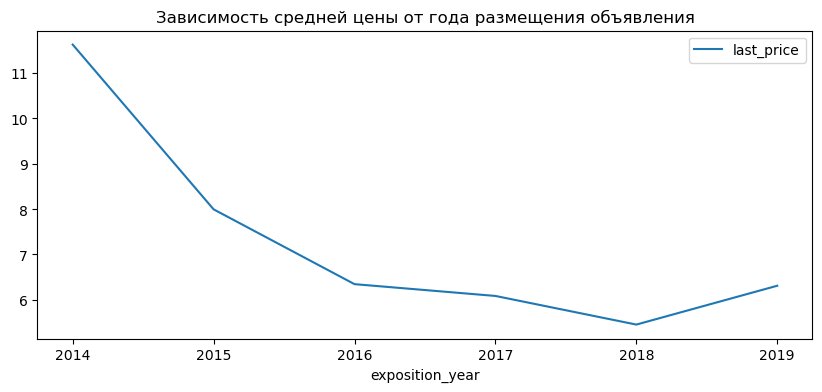

```python
data.pivot_table(index='exposition_year', values='last_price')\
.plot(style='-',title='Зависимость средней цены от года размещения объявления', figsize=(10,4))
plt.show
print('Коэффициент корреляции цены от года размещения объявления', round(data['exposition_year'].corr(data['last_price']), 2))
```

```
Коэффициент корреляции цены  кв.м от года размещения объявления 0.0
```

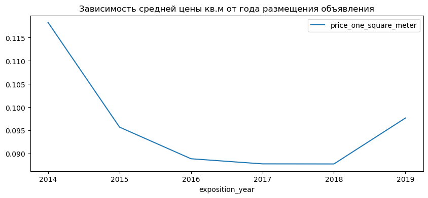

```python
data.pivot_table(index='exposition_year', values='price_one_square_meter')\
.plot(style='-',title='Зависимость средней цены кв.м от года размещения объявления', figsize=(10,4))
plt.show
print('Коэффициент корреляции цены  кв.м от года размещения объявления', round(data['exposition_year'].corr(data['price_one_square_meter']), 2))
```

```
Коэффициент корреляции площади от года размещения объявления -0.08
```

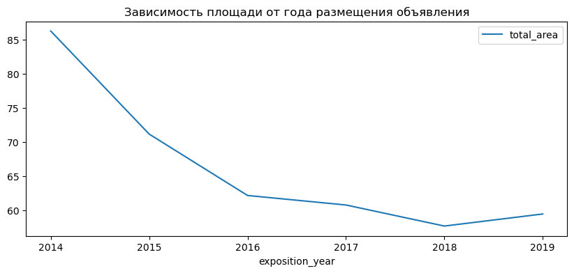

```python
data.pivot_table(index='exposition_year', values='total_area')\
.plot(style='-',title='Зависимость площади от года размещения объявления', figsize=(10,4))
plt.show
print('Коэффициент корреляции площади от года размещения объявления', round(data['exposition_year'].corr(data['total_area']), 2))
```

**Вывод**

### Расчитать среднюю цену одного квадратного метра в 10 населённых пунктах с наибольшим числом объявлений.

Выделить населённые пункты с самой высокой и низкой стоимостью квадратного метра.

```python
# ТОП 10 населенных пунктов с наибольшим числом объявлений

top_10_localities = data_update['locality_name'].value_counts().head(10)
top_10_localities
```

```
locality_name
Санкт-Петербург      12408
посёлок Мурино         518
Кудрово                406
посёлок Шушары         388
Всеволожск             308
Колпино                293
посёлок Парголово      287
Пушкин                 276
Гатчина                244
Выборг                 191
Name: count, dtype: int64
```

```python
# выведем среднюю цену за кв м по топ 10 населенным пунктам

top_10_localities_pivot = data_update.query('locality_name in @top_10_localities.index').pivot_table(index='locality_name', values='price_one_square_meter')
top_10_localities_pivot.sort_values(by='price_one_square_meter', ascending=False)
```

| locality_name | price_one_square_meter |
| --- | --- |
| Санкт-Петербург | 0.102135 |
| Пушкин | 0.092391 |
| Кудрово | 0.082562 |
| посёлок Парголово | 0.078362 |
| посёлок Мурино | 0.073282 |
| посёлок Шушары | 0.068119 |
| Колпино | 0.064437 |
| Всеволожск | 0.058506 |
| Гатчина | 0.057172 |
| Выборг | 0.047068 |

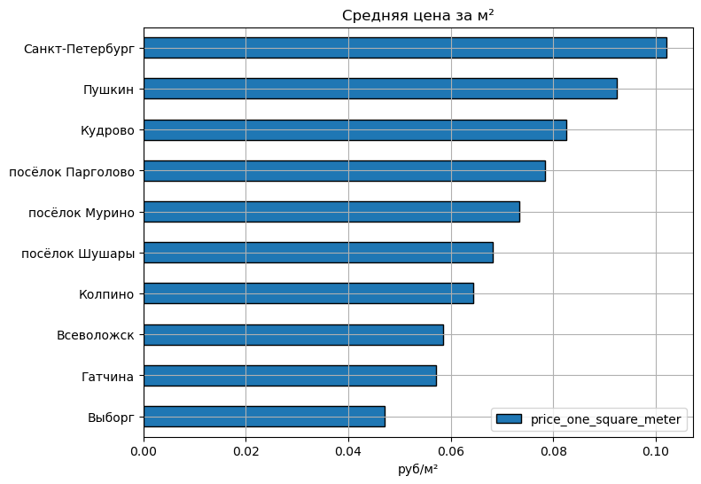

```python
# отобразим на графике среднюю цену квадратного метра в топ 10 населенных пунктах

top_10_localities_pivot.sort_values(by='price_one_square_meter').plot(kind='barh', legend=True, grid=True, ec='black', figsize=(8, 6))
plt.title('Средняя цена за м²')
plt.xlabel('руб/м²')
plt.ylabel('')
plt.show()
```

**Вывод:**

Ранее я посчитал расстояние до центра в километрах. Теперь выделим квартиры в Санкт-Петербурге с помощью столбца locality_name и вычислим среднюю цену каждого километра. Опишим, как стоимость объектов зависит от расстояния до центра города.

```python
# выберем только Санкт-Петербург

df_spb = data_update.query('locality_name == "Санкт-Петербург"')
df_spb.head()
```

|  | total_images | last_price | total_area | first_day_exposition | rooms | ceiling_height | floors_total | living_area | floor | is_apartment | studio | open_plan | kitchen_area | balcony | locality_name | airports_nearest | city_centers_nearest | parks_around_3000 | parks_nearest | ponds_around_3000 | ponds_nearest | days_exposition | price_one_square_meter | exposition_weekday | exposition_month | exposition_year | floor_category | city_centers_nearest_km |
| --- | --- | --- | --- | --- | --- | --- | --- | --- | --- | --- | --- | --- | --- | --- | --- | --- | --- | --- | --- | --- | --- | --- | --- | --- | --- | --- | --- | --- |
| 3 | 0 | 64 | 159.000000 | 2015-07-24 | 3 | 2.65 | 14.0 | NaN | 9 | False | False | False | NaN | 0 | Санкт-Петербург | 28098.0 | 6800.0 | 2.0 | 84.0 | 3.0 | 234.0 | 424.0 | 0.40 | 4 | 7 | 2015 | другой | 7.0 |
| 4 | 2 | 10 | 100.000000 | 2018-06-19 | 2 | 3.03 | 14.0 | 32.000000 | 13 | False | False | False | 41.0 | 0 | Санкт-Петербург | 31856.0 | 8098.0 | 2.0 | 112.0 | 1.0 | 48.0 | 121.0 | 0.10 | 1 | 6 | 2018 | другой | 8.0 |
| 9 | 18 | 5 | 61.000000 | 2017-02-26 | 3 | 2.50 | 9.0 | 43.599998 | 7 | False | False | False | 6.5 | 2 | Санкт-Петербург | 50898.0 | 15008.0 | 0.0 | NaN | 0.0 | NaN | 289.0 | 0.08 | 6 | 2 | 2017 | другой | 15.0 |
| 10 | 5 | 5 | 39.599998 | 2017-11-16 | 1 | 2.67 | 12.0 | 20.299999 | 3 | False | False | False | 8.5 | 0 | Санкт-Петербург | 38357.0 | 13878.0 | 1.0 | 310.0 | 2.0 | 553.0 | 137.0 | 0.13 | 3 | 11 | 2017 | другой | 14.0 |
| 15 | 16 | 4 | 39.000000 | 2017-11-18 | 1 | 2.65 | 14.0 | 20.500000 | 5 | False | False | False | 7.6 | 1 | Санкт-Петербург | 12900.0 | 14259.0 | 1.0 | 590.0 | 1.0 | 296.0 | 19.0 | 0.10 | 5 | 11 | 2017 | другой | 14.0 |

```python
# посмотрим длину получившегося df

len(df_spb)
```

```
12408
```

**Вывод**

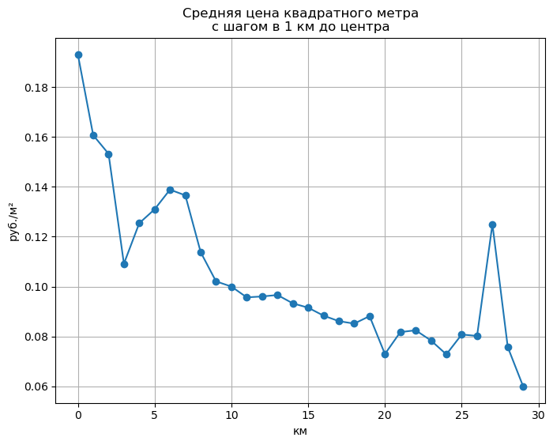

```python
# рассчитаем среднюю цену квадратного метра до центра

(
df_spb
    .pivot_table(index='city_centers_nearest_km', values='price_one_square_meter')
    .plot(marker='o', grid=True, figsize=(8, 6), legend=False)
)
plt.title('Средняя цена квадратного метра\nс шагом в 1 км до центра')
plt.xlabel('км')
plt.ylabel('руб./м²')
plt.show()
```

**Вывод**

Из графика можно заметить, что после 8-го километра форма графика становится линейной и стоимость начинается уменьшаться. Максимальная стоимость в зоне у самого центра (до 1 км). Пик в районе 27 км - возможен из-за класса жилья - элитное.

## Общий вывод

В ходе работы была проведена предобработка данных - устранены некоторые пропуски, некорректные значения. Оптимизированы названия населенных пунктов. Скорее всего, часть некорректных и пропущенных значений является ошибками ввода, часть - следствием невозможности обработать неполный адрес объекта.

В дальнейшем при сборе данных стоит попытаться контролировать получаемые значения - ограничить высоту потолка правдоподобными 6-ю метрами, не пропускать общую этажность дома, площадь кухни, жилую площадь.

Из полученного датасета можно сделать вывод, что в центре Петербурга квартиры дороже, чем на окраине или в городах-спутниках. Студии и однушки по цене квадратного метра являются лидерами, но при этом продаются быстрее всего. К тому же и количество их предложений самое большое.

**Наибольшее влияние на стоимость квартиры оказывает её площадь.** Чем больше площадь квартиры, тем выше её стоимость. Также на стоимость квартиры влияет и количество комнат. Чем больше комнат, тем выше стоимость. На стоимость квартиры также влияет расстояние до центра города. Чем ближе квартира располагается к центру, тем выше ее стоимость. По результатам исследования принял, что зона центра города распространяется на 8 км.

**Мы получили представление о типичном объекте недвижимости:** квартира с 1 или 2 комнатами, 5-ти или 9-ти этажка (с квартирой с 1 по 4 этаж), общей площадью около 45 м², площадью кухни около 5,5 м², с высотой потолков 2,6 м, стоимостью около 3.5 млн.руб, расположенной на удалении от центра на расстоянии 11-16 км, от аэропорта на расстоянии 15-25 км, до ближайшего парка около 500 метров.

**Также установлено:**

Сделаны графики соотношений цены к другим показателям квартир